# Madrid House Price

Sergio Fernández, Miguel Ocón, Enrique Roa

07 de febrero de 2023

[figure not shown]

# 1 Introducción y definición de objetivos

El análisis de datos en el mercado inmobiliario es algo muy común y que lleva muchísimos años desarrollándose. Con el objetivo de predecir que aspectos influyen principalmente en el precio de las casas en Madrid, hemos seleccionado un dataset ([kaggle - Madrid House Price](https://www.kaggle.com/datasets/kevsde/madrid-house-price)) con viviendas en venta de la capital española.

```r
library(readr)
library(dplyr)
library(tidyr)
library(kableExtra)
library(ggplot2)
library(cowplot)
library(ggcorrplot)
library(gmodels)
library(caret)
```

```r
paste(R.Version()$version.string)
```

```
## [1] "R version 4.2.2 (2022-10-31 ucrt)"
```

# 2 Análisis exploratorio inicial

## 2.1 Lectura y preparación de los datos

```r
mhp <- read_csv("house_price_madrid_14_08_2022.csv")
```

```r
head(mhp, 10) %>%
  kbl() %>%
  kable_material(c("striped", "hover")) %>%
  scroll_box(width = "100%", height = "350px")
```

| price | house_type | house_type_2 | rooms | m2 | elevator | garage | neighborhood | district |
| --- | --- | --- | --- | --- | --- | --- | --- | --- |
| 495000 | planta 1 | exterior | 3 | 118 | TRUE | TRUE | Chopera | Arganzuela |
| 485000 | planta 2 | exterior | 2 | 82 | TRUE | TRUE | Palos de Moguer | Arganzuela |
| 315000 | planta 2 | exterior | 2 | 72 | FALSE | FALSE | Legazpi | Arganzuela |
| 585000 | planta 4 | exterior | 2 | 174 | TRUE | TRUE | Palos de Moguer | Arganzuela |
| 255000 | bajo | exterior | 3 | 75 | FALSE | FALSE | Acacias | Arganzuela |
| 299000 | planta 1 | exterior | 1 | 69 | TRUE | FALSE | Chopera | Arganzuela |
| 265000 | planta 3 | exterior | 2 | 54 | TRUE | FALSE | Delicias | Arganzuela |
| 290000 | planta 3 | interior | 4 | 69 | TRUE | FALSE | Chopera | Arganzuela |
| 660220 | planta 2 | exterior | 3 | 129 | TRUE | TRUE | Imperial | Arganzuela |
| 525000 | planta 4 | exterior | 4 | 111 | TRUE | FALSE | Chopera | Arganzuela |

```r
summary(mhp)
```

```
##      price           house_type        house_type_2           rooms
##  Min.   :     725   Length:15975       Length:15975       Min.   : 1.000
##  1st Qu.:  195000   Class :character   Class :character   1st Qu.: 2.000
##  Median :  359973   Mode  :character   Mode  :character   Median : 3.000
##  Mean   :  624233                                         Mean   : 2.848
##  3rd Qu.:  749000                                         3rd Qu.: 3.000
##  Max.   :13950000                                         Max.   :41.000
##        m2         elevator         garage        neighborhood
##  Min.   :  1.0   Mode :logical   Mode :logical   Length:15975
##  1st Qu.: 66.0   FALSE:4597      FALSE:11528     Class :character
##  Median : 93.0   TRUE :11378     TRUE :4447      Mode  :character
##  Mean   :124.8
##  3rd Qu.:142.0
##  Max.   :989.0
##    district
##  Length:15975
##  Class :character
##  Mode  :character
##
##
##
```

```r
str(mhp)
```

```
## spc_tbl_ [15,975 × 9] (S3: spec_tbl_df/tbl_df/tbl/data.frame)
##  $ price       : num [1:15975] 495000 485000 315000 585000 255000 ...
##  $ house_type  : chr [1:15975] "planta 1" "planta 2" "planta 2" "planta 4" ...
##  $ house_type_2: chr [1:15975] "exterior" "exterior" "exterior" "exterior" ...
##  $ rooms       : num [1:15975] 3 2 2 2 3 1 2 4 3 4 ...
##  $ m2          : num [1:15975] 118 82 72 174 75 69 54 69 129 111 ...
##  $ elevator    : logi [1:15975] TRUE TRUE FALSE TRUE FALSE TRUE ...
##  $ garage      : logi [1:15975] TRUE TRUE FALSE TRUE FALSE FALSE ...
##  $ neighborhood: chr [1:15975] "Chopera" "Palos de Moguer" "Legazpi" "Palos de Moguer" ...
##  $ district    : chr [1:15975] "Arganzuela" "Arganzuela" "Arganzuela" "Arganzuela" ...
##  - attr(*, "spec")=
##   .. cols(
##   ..   price = col_double(),
##   ..   house_type = col_character(),
##   ..   house_type_2 = col_character(),
##   ..   rooms = col_double(),
##   ..   m2 = col_double(),
##   ..   elevator = col_logical(),
##   ..   garage = col_logical(),
##   ..   neighborhood = col_character(),
##   ..   district = col_character()
##   .. )
##  - attr(*, "problems")=<externalptr>
```

El dataset contiene **15.975 observaciones** (correspondientes a una vivienda cada una) y **9 variables** (de las cuales son **6 cualitativas** y **3 cuantitativas**).

A continuación, la descripción de cada una de las variables:

- **price**: precio
- **house_type**: tipo de vivienda (casa, chalet, piso…)
- **house_type_2**: si es exterior o interior
- **rooms**: número de habitaciones
- **m2**: metros cuadrados
- **elevator**: si tiene ascensor
- **garage**: si incluye garaje
- **neighborhood**: barrio de Madrid
- **district**: distrito de Madrid

## 2.2 Tratamiento de datos faltantes

Convertimos en NA las siguientes observaciones:

- La casa de 41 habitaciones (probablemente fueran 4 y está mal imputado)
- Las que tienen menos de 3 m2 (probablemente mal imputados al usar el punto para separar los miles)
- La casa con un precio de 725 (claramente equivocado).

```r
mhp$rooms[mhp$rooms > 40] <- NA
mhp$m2[mhp$m2 < 3] <- NA
mhp$price[mhp$price < 1000] <- NA
```

La variable **house_type_2** tiene 469 filas sin datos. Junto a los añadidos anteriormente son el 3.2% del total. Optamos por eliminar estas filas del dataset.

```r
sum(is.na(mhp))/nrow(mhp)
```

```
## [1] 0.03205008
```

```r
mhp <- na.omit(mhp)
```

## 2.3 Procesado de variables categóricas

```r
mhp <- mhp %>% rename(exterior = house_type_2)

mhp$exterior = ifelse(mhp$exterior == "exterior", 1, 0)
mhp$exterior = factor(mhp$exterior, levels = c(1,0))

mhp$elevator = ifelse(mhp$elevator == "TRUE", 1, 0)
mhp$elevator = factor(mhp$elevator, levels = c(1,0))

mhp$garage = ifelse(mhp$garage == "TRUE", 1, 0)
mhp$garage = factor(mhp$garage, levels = c(1,0))
```

```r
mhp$house_type <- as.factor(mhp$house_type)
mhp$exterior <- as.factor(mhp$exterior)
mhp$elevator <- as.factor(mhp$elevator)
mhp$garage <- as.factor(mhp$garage)
mhp$neighborhood <- as.factor(mhp$neighborhood)
mhp$district <- as.factor(mhp$district)

mhp$house_type <- factor(mhp$house_type, ordered = TRUE, levels = c("planta -1", "sotano", "semi-sotano", "casa", "chalet", "entreplanta", "bajo", "planta 1", "planta 2", "planta 3", "planta 4", "planta 5", "planta 6", "planta 7", "planta 8", "planta 9", "planta 10", "planta 11", "planta 12", "planta 13", "planta 14", "planta 15", "planta 16", "planta 17", "planta 18", "planta 19", "planta 20"))
```

## 2.4 División del dataset

Dividimos el dataset en 70/30.

```r
set.seed(108)
particion <- createDataPartition(mhp$district, p = 0.7, list = FALSE)

mhp_train <- mhp[particion, ]
mhp_test <- mhp[-particion, ]
```

# 3 Análisis univariante

## 3.1 Análisis de variables cualitativas

**TIPO DE VIVIENDA**

```r
merge(setNames(as.data.frame(table(mhp_train$house_type)), c("house_type", "count")),
      setNames(as.data.frame(round(prop.table(table(mhp_train$house_type))*100, 2)), c("house_type", "prop (%)"))
) %>%
  arrange(desc(count)) %>%
  kbl() %>%
  kable_material(c("striped", "hover")) %>%
  scroll_box(width = "100%", height = "350px")
```

| house_type | count | prop (%) |
| --- | --- | --- |
| planta 1 | 2209 | 20.39 |
| planta 2 | 1923 | 17.75 |
| planta 3 | 1695 | 15.65 |
| bajo | 1362 | 12.57 |
| planta 4 | 1158 | 10.69 |
| planta 5 | 716 | 6.61 |
| planta 6 | 448 | 4.14 |
| planta 7 | 270 | 2.49 |
| chalet | 263 | 2.43 |
| entreplanta | 182 | 1.68 |
| planta 8 | 145 | 1.34 |
| planta 9 | 105 | 0.97 |
| casa | 83 | 0.77 |
| planta 10 | 57 | 0.53 |
| semi-sotano | 50 | 0.46 |
| planta 11 | 34 | 0.31 |
| planta 12 | 28 | 0.26 |
| planta 13 | 26 | 0.24 |
| sotano | 23 | 0.21 |
| planta 14 | 14 | 0.13 |
| planta -1 | 12 | 0.11 |
| planta 15 | 9 | 0.08 |
| planta 16 | 5 | 0.05 |
| planta 18 | 5 | 0.05 |
| planta 19 | 5 | 0.05 |
| planta 20 | 5 | 0.05 |
| planta 17 | 0 | 0.00 |

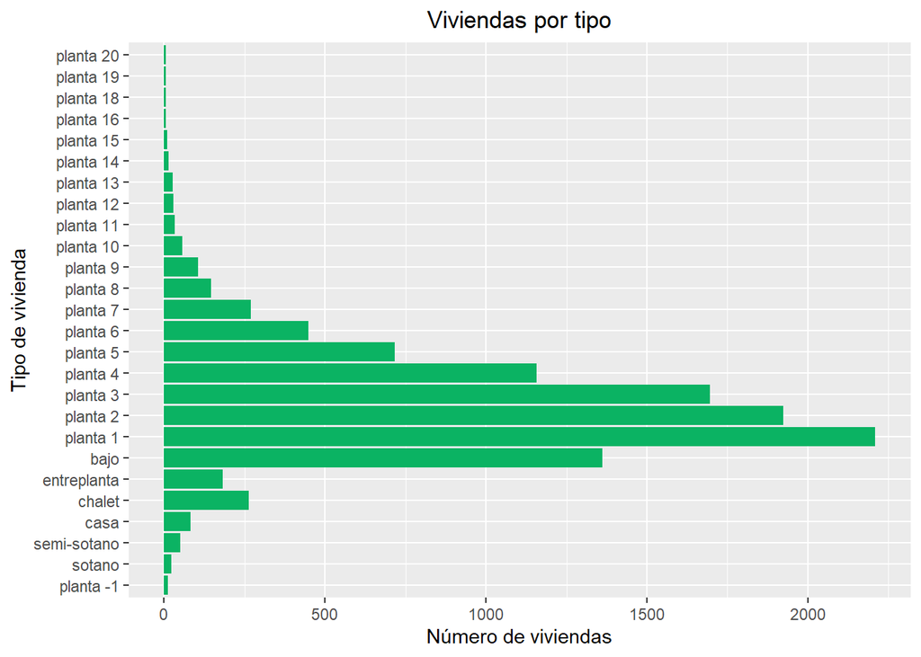

```r
ggplot(mhp_train, aes(house_type)) +
  geom_bar(fill = "#0BB363") +
  coord_flip() +
  labs(x = "Tipo de vivienda", y = "Número de viviendas", title = "Viviendas por tipo") +
  theme(plot.title = element_text(hjust = 0.5))
```

**EXTERIOR**

```r
merge(setNames(as.data.frame(table(mhp_train$exterior)), c("exterior", "count")),
      setNames(as.data.frame(round(prop.table(table(mhp_train$exterior))*100, 2)), c("exterior", "prop (%)"))
) %>%
  kbl() %>%
  kable_material(c("striped", "hover"))
```

| exterior | count | prop (%) |
| --- | --- | --- |
| 0 | 1162 | 10.73 |
| 1 | 9670 | 89.27 |

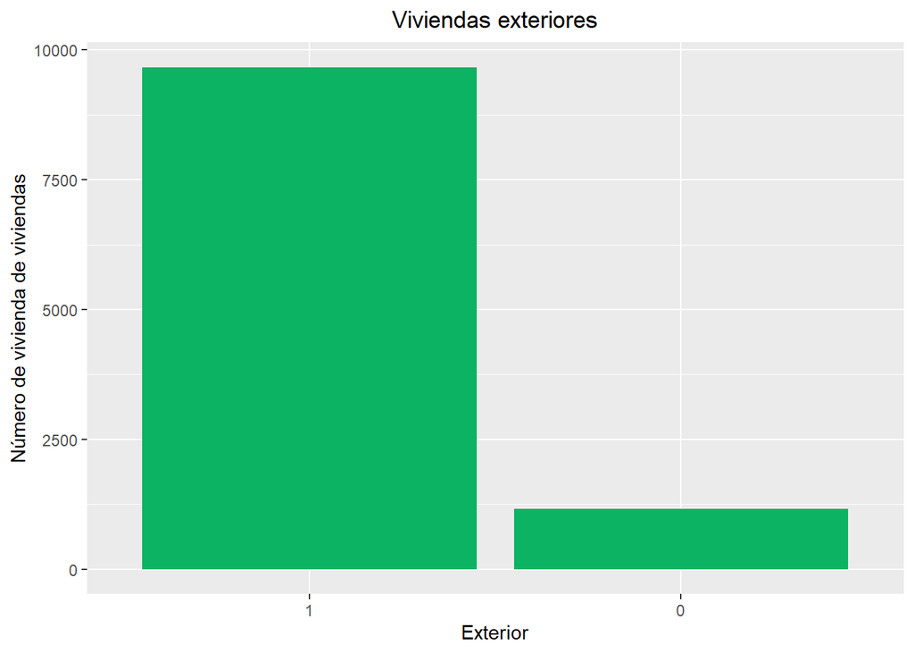

```r
ggplot(mhp_train, aes(exterior)) +
  geom_bar(fill = "#0BB363") +
  labs(x = "Exterior", y = "Número de vivienda de viviendas", title = "Viviendas exteriores") +
  theme(plot.title = element_text(hjust = 0.5))
```

**ASCENSOR**

```r
merge(setNames(as.data.frame(table(mhp_train$elevator)), c("elevator", "count")),
      setNames(as.data.frame(round(prop.table(table(mhp_train$elevator))*100, 2)), c("elevator", "prop (%)"))
) %>%
  kbl() %>%
  kable_material(c("striped", "hover"))
```

| elevator | count | prop (%) |
| --- | --- | --- |
| 0 | 2993 | 27.63 |
| 1 | 7839 | 72.37 |

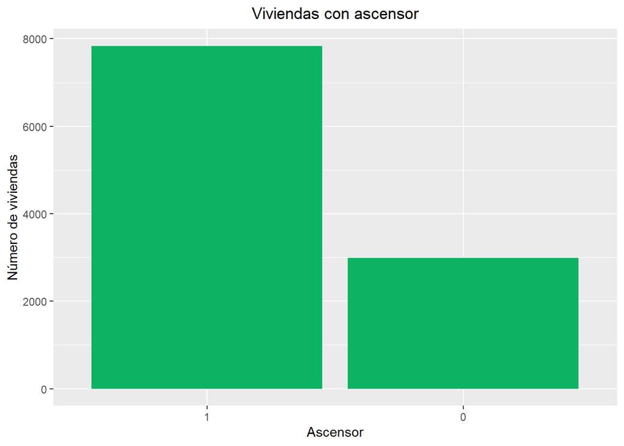

```r
ggplot(mhp_train, aes(elevator)) +
  geom_bar(fill = "#0BB363") +
  labs(x = "Ascensor", y = "Número de viviendas", title = "Viviendas con ascensor") +
  theme(plot.title = element_text(hjust = 0.5))
```

**GARAJE**

```r
merge(setNames(as.data.frame(table(mhp_train$garage)), c("garage", "count")),
      setNames(as.data.frame(round(prop.table(table(mhp_train$garage))*100, 2)), c("garage", "prop (%)"))
) %>%
  kbl() %>%
  kable_material(c("striped", "hover"))
```

| garage | count | prop (%) |
| --- | --- | --- |
| 0 | 7766 | 71.69 |
| 1 | 3066 | 28.31 |

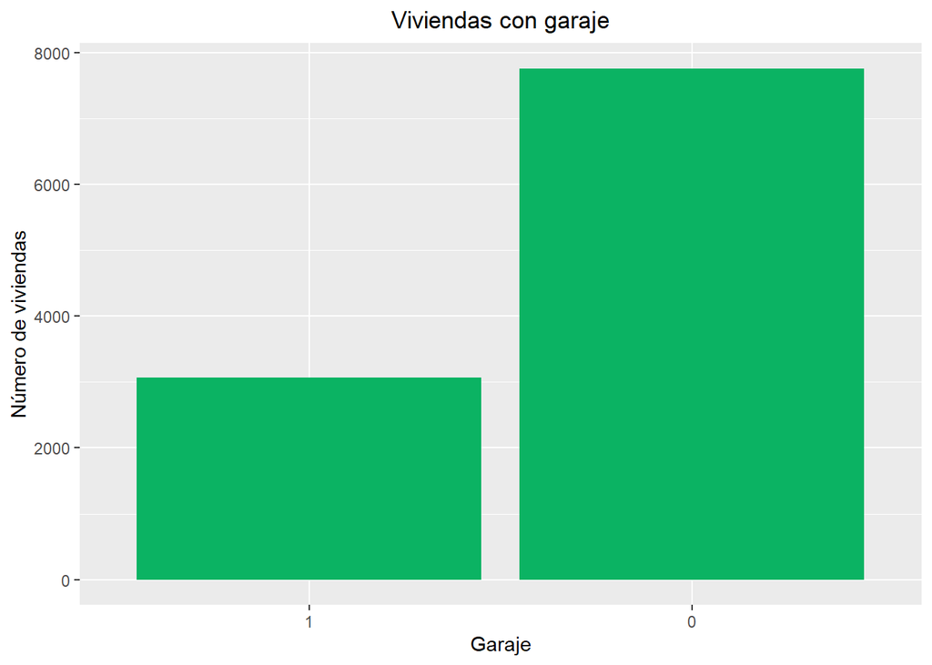

```r
ggplot(mhp_train, aes(garage)) +
  geom_bar(fill = "#0BB363") +
  labs(x = "Garaje", y = "Número de viviendas", title = "Viviendas con garaje") +
  theme(plot.title = element_text(hjust = 0.5))
```

**BARRIO**

```r
merge(setNames(as.data.frame(table(mhp_train$neighborhood)), c("neighborhood", "count")),
      setNames(as.data.frame(round(prop.table(table(mhp_train$neighborhood))*100, 2)), c("neighborhood", "prop (%)"))
) %>%
  kbl() %>%
  kable_material(c("striped", "hover")) %>%
  scroll_box(width = "100%", height = "350px")
```

| neighborhood | count | prop (%) |
| --- | --- | --- |
| 12 de Octubre-Orcasur | 33 | 0.30 |
| Abrantes | 72 | 0.66 |
| Acacias | 64 | 0.59 |
| Adelfas | 49 | 0.45 |
| Aeropuerto | 5 | 0.05 |
| Águilas | 46 | 0.42 |
| Alameda de Osuna | 41 | 0.38 |
| Almagro | 175 | 1.62 |
| Almendrales | 49 | 0.45 |
| Aluche | 87 | 0.80 |
| Ambroz | 39 | 0.36 |
| Amposta | 27 | 0.25 |
| Apóstol Santiago | 25 | 0.23 |
| Arapiles | 93 | 0.86 |
| Aravaca | 63 | 0.58 |
| Arcos | 34 | 0.31 |
| Argüelles | 187 | 1.73 |
| Arroyo del Fresno | 15 | 0.14 |
| Atalaya | 7 | 0.06 |
| Ático en Almagro | 8 | 0.07 |
| Ático en Arapiles | 2 | 0.02 |
| Ático en Aravaca | 1 | 0.01 |
| Ático en Arcos | 1 | 0.01 |
| Ático en Argüelles | 3 | 0.03 |
| Ático en Bernabéu-Hispanoamérica | 2 | 0.02 |
| Ático en Campo de las Naciones-Corralejos | 0 | 0.00 |
| Ático en Castellana | 10 | 0.09 |
| Ático en Castilla | 2 | 0.02 |
| Ático en Chueca-Justicia | 1 | 0.01 |
| Ático en Ciudad Universitaria | 0 | 0.00 |

[output cut: 306 more lines]

**DISTRITO**

```r
merge(setNames(as.data.frame(table(mhp_train$district)), c("district", "count")),
      setNames(as.data.frame(round(prop.table(table(mhp_train$district))*100, 2)), c("district", "prop (%)"))
) %>%
  arrange(desc(count)) %>%
  kbl() %>%
  kable_material(c("striped", "hover")) %>%
  scroll_box(width = "100%", height = "350px")
```

| district | count | prop (%) |
| --- | --- | --- |
| barrio de salamanca | 1251 | 11.55 |
| chamberi | 771 | 7.12 |
| tetuan | 757 | 6.99 |
| ciudad lineal | 749 | 6.91 |
| chamartin | 742 | 6.85 |
| centro | 741 | 6.84 |
| carabanchel | 721 | 6.66 |
| puente-de-vallecas | 521 | 4.81 |
| hortaleza | 499 | 4.61 |
| fuencarral | 491 | 4.53 |
| latina | 484 | 4.47 |
| moncloa | 476 | 4.39 |
| san-blas | 455 | 4.20 |
| Arganzuela | 424 | 3.91 |
| retiro | 416 | 3.84 |
| usera | 332 | 3.06 |
| villaverde | 313 | 2.89 |
| villa-de-vallecas | 236 | 2.18 |
| vicalvaro | 192 | 1.77 |
| moratalaz | 139 | 1.28 |
| barajas | 122 | 1.13 |

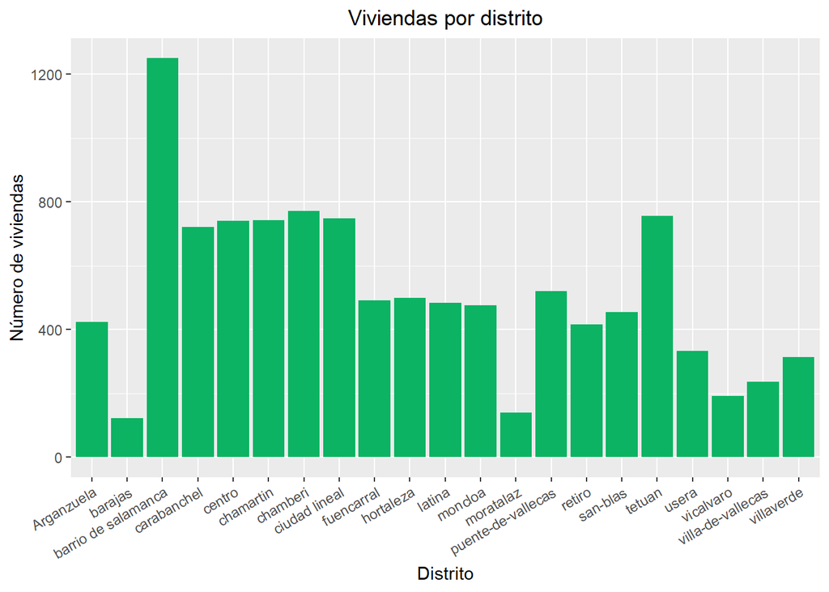

```r
ggplot(mhp_train, aes(district)) +
  geom_bar(fill = "#0BB363") +
  labs(x = "Distrito", y = "Número de viviendas", title = "Viviendas por distrito") +
  theme(plot.title = element_text(hjust = 0.5), axis.text.x = element_text(angle = 30, hjust = 1))
```

## 3.2 Análisis de variables cuantitativas

**PRECIO**

```r
data.frame(summarise(mhp_train,
                     min = min(price),
                     max = max(price),
                     median = median(price),
                     mean = mean(price),
                     sd = sd(price))) %>%
  kbl() %>%
  kable_material(c("striped", "hover"))
```

| min | max | median | mean | sd |
| --- | --- | --- | --- | --- |
| 47500 | 11200000 | 367100 | 623903.5 | 741116.4 |

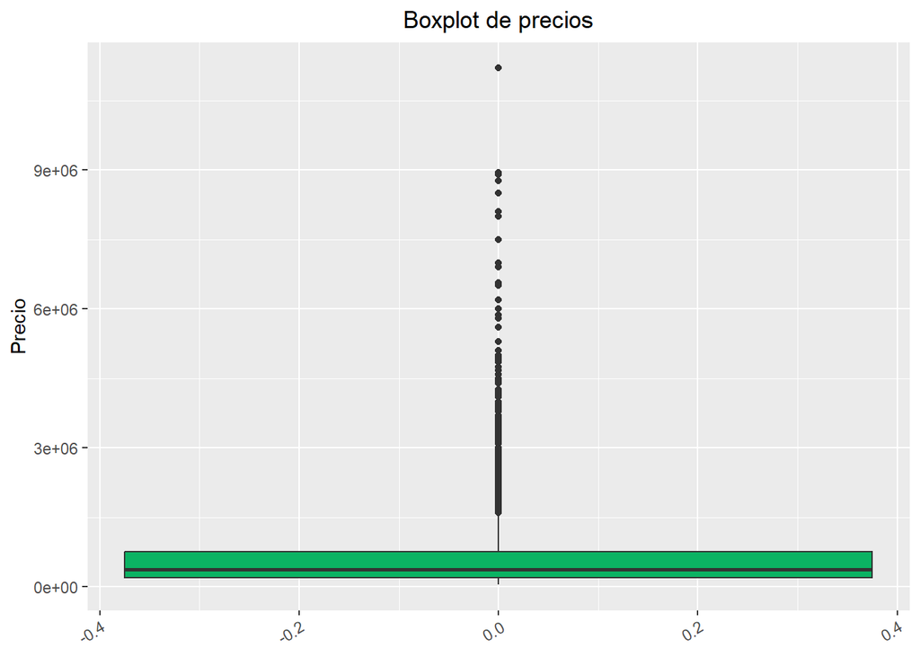

```r
ggplot(mhp_train, aes(y = price)) +
  geom_boxplot(fill = "#0BB363") +
  labs(y = "Precio", title = "Boxplot de precios") +
  theme(plot.title = element_text(hjust = 0.5), axis.text.x = element_text(angle = 30, hjust = 1))
```

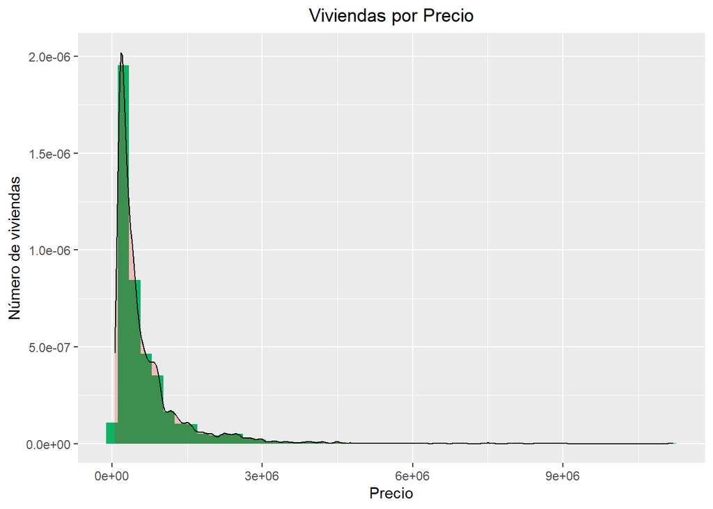

```r
ggplot(mhp_train, aes(price)) +
  geom_histogram(aes(y=..density..), bins = 50, position = "dodge", fill = "#0BB363") +
  geom_density(alpha=.2, fill = "red") +
  labs(x = "Precio", y = "Número de viviendas", title = "Viviendas por Precio") +
  theme(plot.title = element_text(hjust = 0.5))
```

**HABITACIONES**

```r
data.frame(summarise(mhp_train,
                     min = min(rooms),
                     max = max(rooms),
                     median = median(rooms),
                     mean = mean(rooms),
                     sd = sd(rooms))) %>%
  kbl() %>%
  kable_material(c("striped", "hover"))
```

| min | max | median | mean | sd |
| --- | --- | --- | --- | --- |
| 1 | 16 | 3 | 2.838626 | 1.296783 |

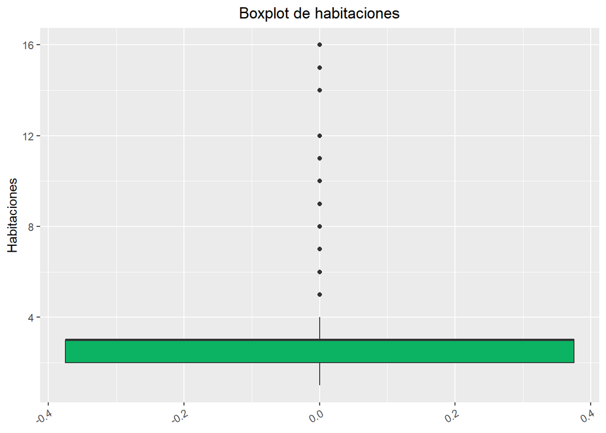

```r
ggplot(mhp_train, aes(y = rooms)) +
  geom_boxplot(fill = "#0BB363") +
  labs(y = "Habitaciones", title = "Boxplot de habitaciones") +
  theme(plot.title = element_text(hjust = 0.5), axis.text.x = element_text(angle = 30, hjust = 1))
```

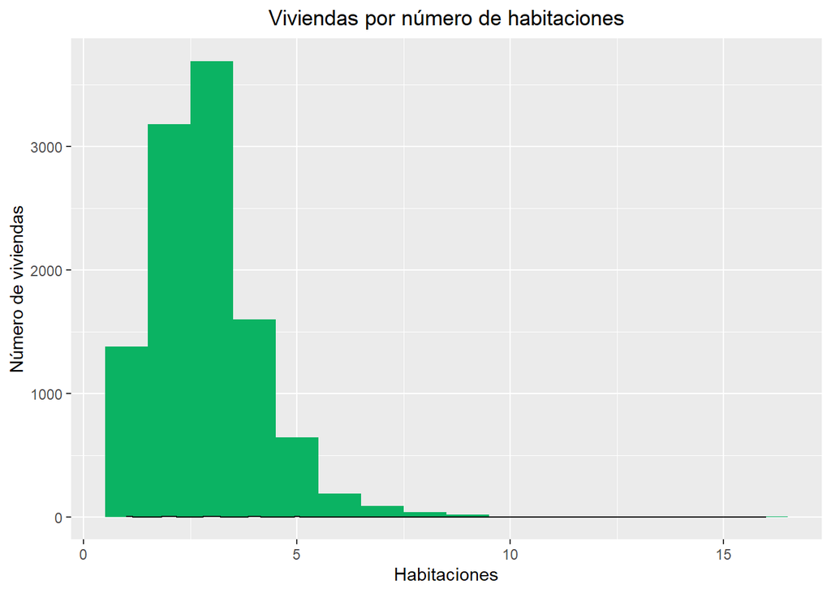

```r
ggplot(mhp_train, aes(rooms)) +
  geom_histogram(aes(), bins = 16, position = "dodge", fill = "#0BB363") +
  geom_density(alpha=.2, fill = "red") +
  labs(x = "Habitaciones", y = "Número de viviendas", title = "Viviendas por número de habitaciones") +
  theme(plot.title = element_text(hjust = 0.5))
```

**M²**

```r
data.frame(summarise(mhp_train,
                     min = min(m2),
                     max = max(m2),
                     median = median(m2),
                     mean = mean(m2),
                     sd = sd(m2))) %>%
  kbl() %>%
  kable_material(c("striped", "hover"))
```

| min | max | median | mean | sd |
| --- | --- | --- | --- | --- |
| 20 | 989 | 95 | 126.1617 | 101.0486 |

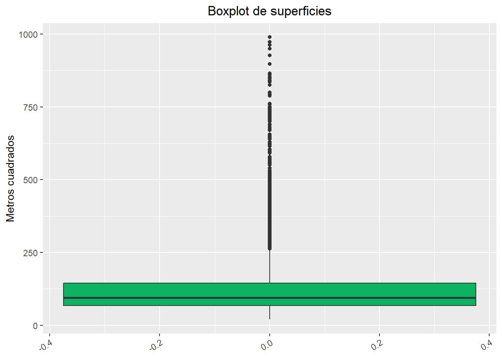

```r
ggplot(mhp_train, aes(y = m2)) +
  geom_boxplot(fill = "#0BB363") +
  labs(y = "Metros cuadrados", title = "Boxplot de superficies") +
  theme(plot.title = element_text(hjust = 0.5), axis.text.x = element_text(angle = 30, hjust = 1))
```

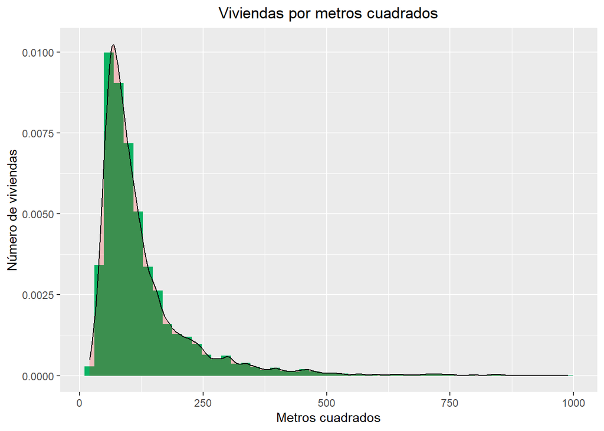

```r
ggplot(mhp_train, aes(m2)) +
  geom_histogram(aes(y=..density..), bins = 50, position = "dodge", fill = "#0BB363") +
  geom_density(alpha=.2, fill = "red") +
  labs(x = "Metros cuadrados", y = "Número de viviendas", title = "Viviendas por metros cuadrados") +
  theme(plot.title = element_text(hjust = 0.5))
```

# 4 Análisis multivariante

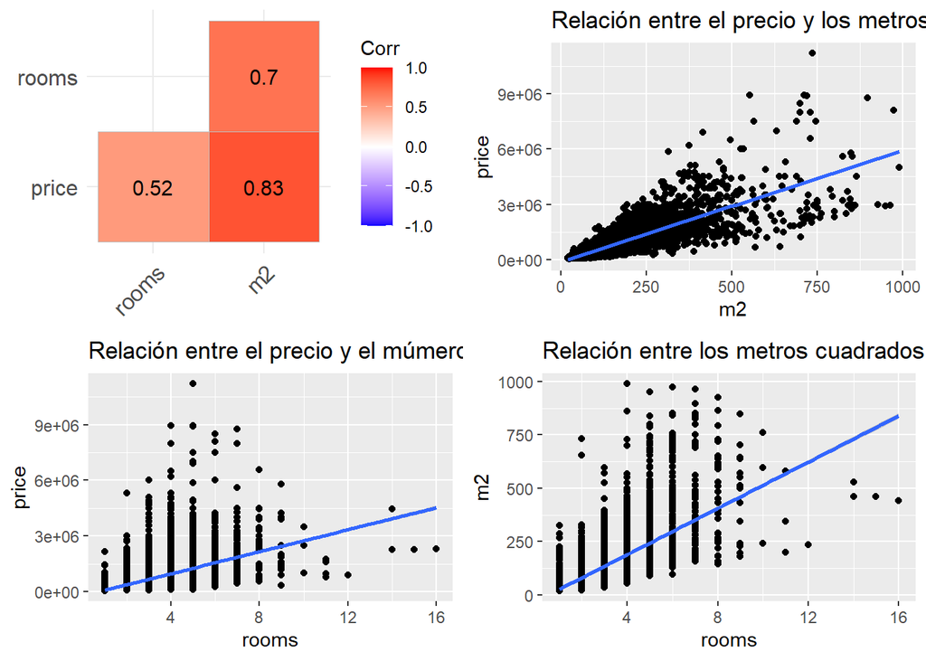

```r
plot_grid(
  ggcorrplot(cor(mhp_train %>% select_if(is.numeric)),type = "lower", lab=TRUE),

  ggplot(mhp_train, aes(x = m2, y = price)) +
  geom_point() +
  geom_smooth(method = "lm") +
  ggtitle('Relación entre el precio y los metros cuadrados'),

  ggplot(mhp_train, aes(x = rooms, y = price)) +
  geom_point() +
  geom_smooth(method = "lm") +
  ggtitle('Relación entre el precio y el múmero de habitaciones'),

  ggplot(mhp_train, aes(x = rooms, y = m2)) +
  geom_point() +
  geom_smooth(method = "lm") +
  ggtitle('Relación entre los metros cuadrados y el número de habitaciones'),

  nrow = 2
)
```

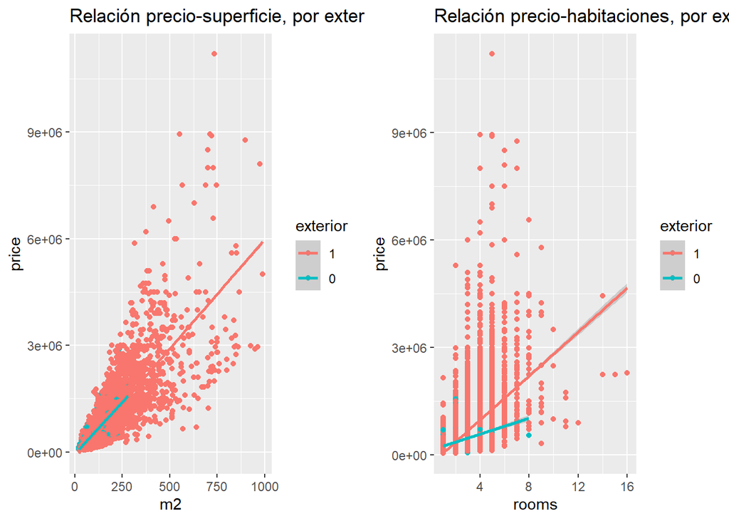

```r
plot_grid(
  ggplot(mhp_train, aes(x = m2, y = price, colour = exterior)) +
  geom_point() +
  geom_smooth(method = "lm") +
  ggtitle('Relación precio-superficie, por exterior'),

  ggplot(mhp_train, aes(x = rooms, y = price, colour = exterior)) +
  geom_point() +
  geom_smooth(method = "lm") +
  ggtitle('Relación precio-habitaciones, por exterior'),

  nrow =1
)
```

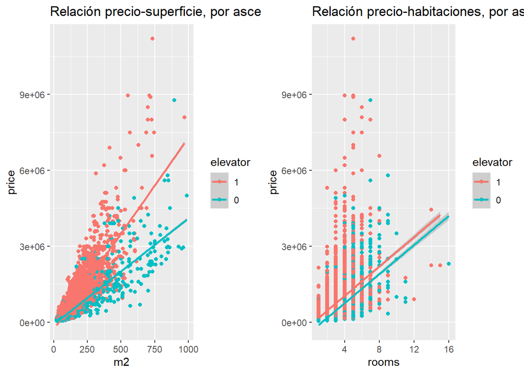

```r
plot_grid(
  ggplot(mhp_train, aes(x = m2, y = price, colour = elevator)) +
  geom_point() +
  geom_smooth(method = "lm") +
  ggtitle('Relación precio-superficie, por ascensor'),

  ggplot(mhp_train, aes(x = rooms, y = price, colour = elevator)) +
  geom_point() +
  geom_smooth(method = "lm") +
  ggtitle('Relación precio-habitaciones, por ascensor'),

  nrow =1
)
```

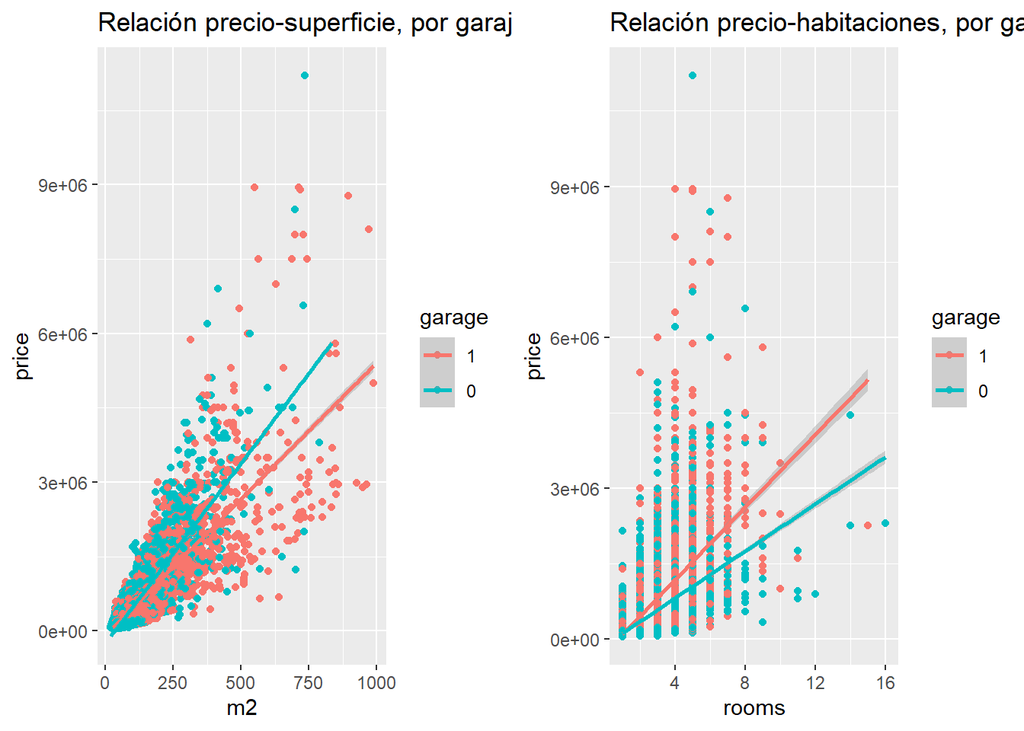

```r
plot_grid(
  ggplot(mhp_train, aes(x = m2, y = price, colour = garage)) +
  geom_point() +
  geom_smooth(method = "lm") +
  ggtitle('Relación precio-superficie, por garaje'),

  ggplot(mhp_train, aes(x = rooms, y = price, colour = garage)) +
  geom_point() +
  geom_smooth(method = "lm") +
  ggtitle('Relación precio-habitaciones, por garaje'),

  nrow =1
)
```

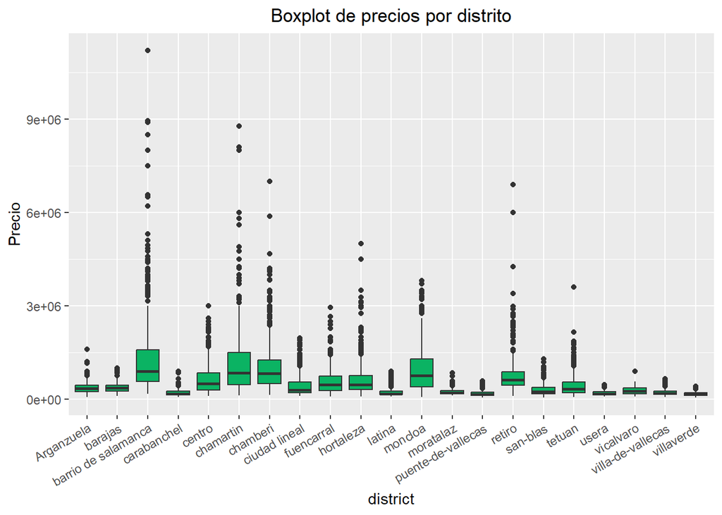

```r
ggplot(mhp_train, aes(district, price)) +
  geom_boxplot(fill = "#0BB363") +
  labs(y = "Precio", title = "Boxplot de precios por distrito") +
  theme(plot.title = element_text(hjust = 0.5), axis.text.x = element_text(angle = 30, hjust = 1))
```

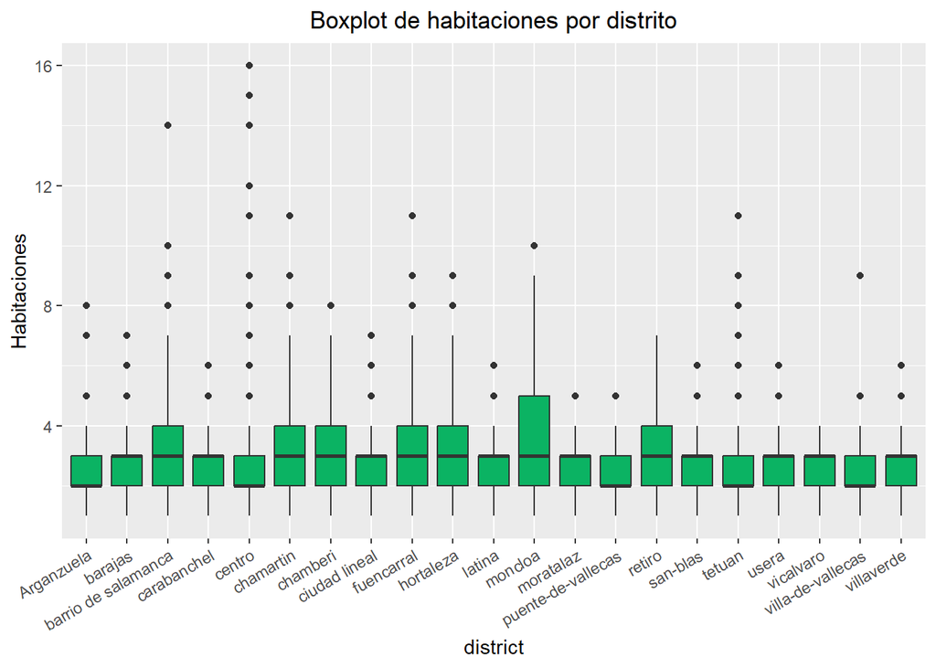

```r
ggplot(mhp_train, aes(district, rooms)) +
  geom_boxplot(fill = "#0BB363") +
  labs(y = "Habitaciones", title = "Boxplot de habitaciones por distrito") +
  theme(plot.title = element_text(hjust = 0.5), axis.text.x = element_text(angle = 30, hjust = 1))
```

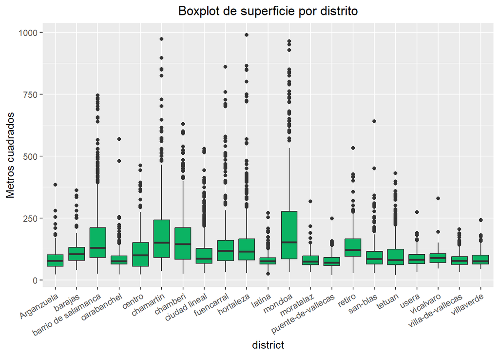

```r
ggplot(mhp_train, aes(district, m2)) +
  geom_boxplot(fill = "#0BB363") +
  labs(y = "Metros cuadrados", title = "Boxplot de superficie por distrito") +
  theme(plot.title = element_text(hjust = 0.5), axis.text.x = element_text(angle = 30, hjust = 1))
```

[figure not shown]

```r
plot_grid(
  ggplot(mhp_train, aes(x = m2, y = price, colour = district)) +
  geom_point() +
  geom_smooth(method = "lm") +
  ggtitle('Relación entre el precio y la superficie, por distrito'),

  ggplot(mhp_train, aes(x = rooms, y = price, colour = district)) +
  geom_point() +
  geom_smooth(method = "lm") +
  ggtitle('Relación entre el precio y las habitaciones, por distrito'),

  nrow =1
)
```

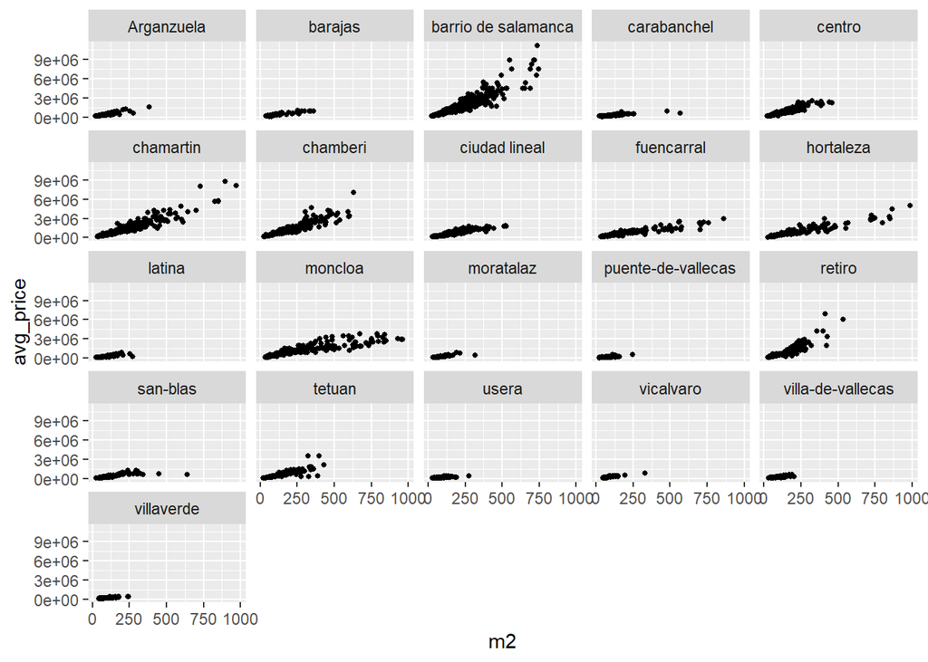

```r
mhp_train %>%
  group_by(district, m2) %>%
  summarize(avg_price = mean(price)) %>%
  ggplot(aes(x = m2, y = avg_price)) +
  geom_point(size = 1) +
  facet_wrap(~ district)
```

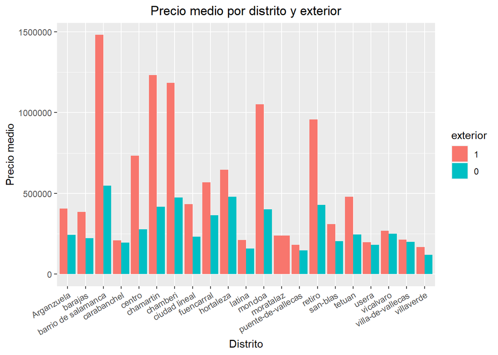

```r
mhp_train %>%
  group_by(district, exterior) %>%
  summarise(avg_price = mean(price)) %>%
  ggplot(aes(x=district, y=avg_price, fill=exterior)) +
  geom_bar(stat = "identity", position = "dodge") +
  ggtitle("Precio medio por distrito y exterior") +
  theme(plot.title = element_text(hjust = 0.5), axis.text.x = element_text(angle = 30, hjust = 1)) +
  labs(x = "Distrito", y = "Precio medio")
```

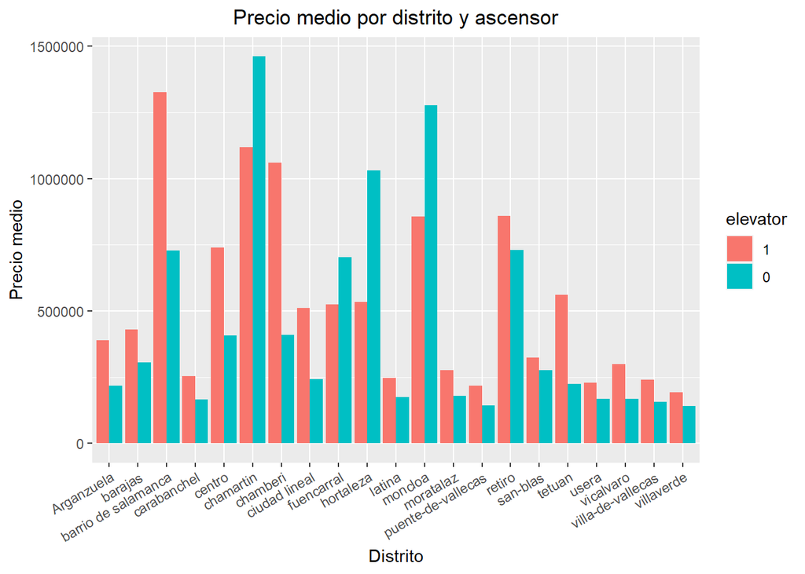

```r
mhp_train %>%
  group_by(district, elevator) %>%
  summarise(avg_price = mean(price)) %>%
  ggplot(aes(x=district, y=avg_price, fill=elevator)) +
  geom_bar(stat = "identity", position = "dodge") +
  ggtitle("Precio medio por distrito y ascensor") +
  theme(plot.title = element_text(hjust = 0.5), axis.text.x = element_text(angle = 30, hjust = 1)) +
  labs(x = "Distrito", y = "Precio medio")
```

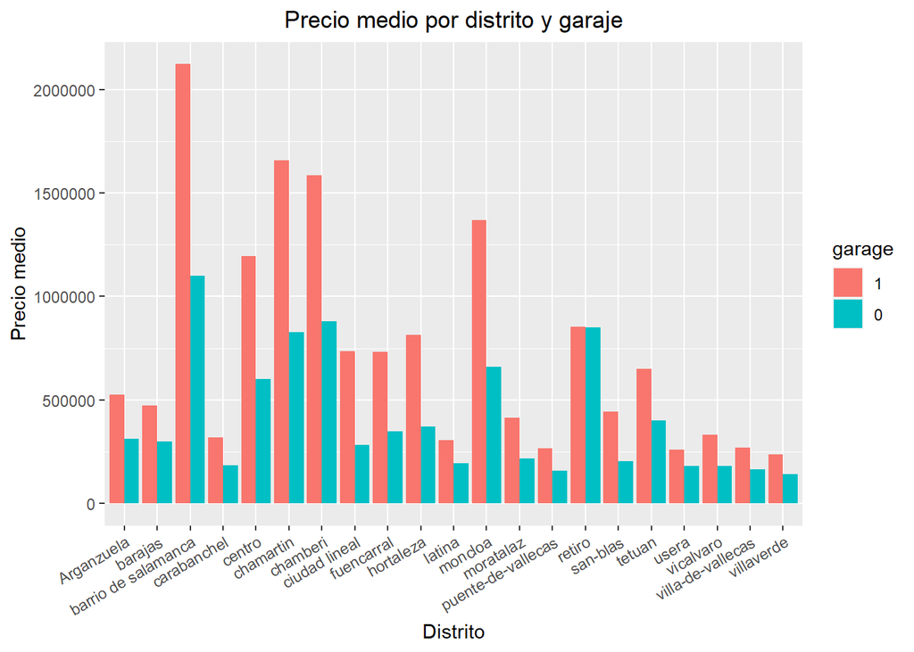

```r
mhp_train %>%
  group_by(district, garage) %>%
  summarise(avg_price = mean(price)) %>%
  ggplot(aes(x=district, y=avg_price, fill=garage)) +
  geom_bar(stat = "identity", position = "dodge") +
  ggtitle("Precio medio por distrito y garaje") +
  theme(plot.title = element_text(hjust = 0.5), axis.text.x = element_text(angle = 30, hjust = 1)) +
  labs(x = "Distrito", y = "Precio medio")
```

# 5 Transformación de variables

## 5.1 Transformación de variables cuantitativas

# 6 Modelo de regresión lineal

# 7 Conclusiones preliminares

# 8 Aprendizaje no supervisado

# 9 Técnicas de reducción de la dimensión

# 10 Aprendizaje supervisado

## 10.1 GLM

## 10.2 KNN

## 10.3 Decision Trees

## 10.4 Random Forest

## 10.5 SVM

# 11 Ajuste de hiperparámetros del modelo

# 12 Evaluación y comparación de modelos

# 13 Elección punto de corte

# 14 Redes Bayasianas y/o GAM